# 1226_QUIZ

## 1. 다이어트 식품의 효과

**1) 복용전과 후의 참가자들의 빈도수와 몸무게 평균값을 구하고, 분포를 그래프로 나타내 보세요.(그래프)**

```r
# 데이터 준비
diet <- read.csv('data/diet_effect.csv')
head(diet)
```

```
##   id before after
## 1  1   53.2  51.6
## 2  2   74.8  72.2
## 3  3   60.3  40.7
## 4  4   79.0  48.9
## 5  5   63.0 999.0
## 6  6   54.0  67.9
```

```r
# 데이터 정제 - 이상치 확인
table(diet$before)
```

```
##
## 50.1 50.3 50.4 50.5 50.6 50.8 50.9 51.3 52.1 52.2 52.3 52.5 52.6 52.7 52.9   53
##    1    1    1    1    1    1    1    1    1    1    1    1    2    3    1    3
## 53.1 53.2 53.4 53.9   54 54.1 54.2 54.4 54.5 54.6 54.7 54.8 54.9 55.1 55.3 55.4
##    1    1    1    1    2    1    1    1    1    1    1    1    3    1    2    3
## 55.5 55.6 55.7 55.9   56 56.2 56.3 56.5 56.7 56.8   57 57.1 57.2 57.3 57.7 58.1
##    1    1    1    1    2    1    1    2    2    1    2    2    1    1    1    2
## 58.3 58.6 58.7 58.9 59.1 59.3 59.6 59.7 59.8   60 60.1 60.2 60.3 60.4 60.7 60.9
##    1    1    1    1    2    1    2    3    1    1    1    2    4    1    1    4
## 61.1 61.2 61.3 61.4 61.7 61.8 61.9   62 62.1 62.2 62.3 62.4 62.5 62.7   63 63.3
##    1    1    3    1    1    1    3    1    1    1    1    1    5    1    1    1
## 63.4 63.7 63.9 64.2 64.3 64.4 64.9 65.2 65.3   66 66.1 66.4 66.5 66.6 66.7 66.8
##    1    1    1    2    2    4    1    1    2    1    2    2    1    2    2    1
## 66.9 67.1 67.3 67.6 67.9   68 68.1 68.4 68.5 68.6 68.7   69 69.1 69.2 69.4 69.5
##    1    2    2    1    1    1    1    1    1    1    1    1    3    2    2    1
## 69.6 69.8 69.9 70.2 70.4 70.5 70.6 70.7 70.8 70.9   71 71.4 71.5 71.7 71.9 72.3
##    3    2    1    2    2    1    3    1    1    1    1    3    1    2    1    1
## 72.4 72.6 72.7 72.9   73 73.2 73.3 73.4 73.7 74.1 74.4 74.6 74.7 74.8 74.9 75.1
##    1    2    2    3    1    1    1    2    1    1    1    1    1    1    1    1
## 75.4 75.7 75.9   76 76.1 76.7 76.8 76.9   77 77.1 77.4 77.7 77.9 78.1 78.3 78.4
##    2    2    1    2    1    1    1    1    2    2    1    1    2    1    1    2
## 78.5 78.6 78.7 78.8   79 79.1 79.2 79.3 79.6 79.9 80.2 80.4 80.7 80.8 80.9   81
##    2    1    1    1    1    1    1    2    3    2    1    1    1    2    1    3
```

```r
table(diet$after)
```

```
##
## 40.1 40.7 40.8 40.9 41.2 41.3 41.6 41.7 41.9 42.1 42.6 42.8 42.9   43 43.2 43.3
##    1    2    1    1    1    1    1    1    1    1    1    1    2    2    1    2
## 43.6 43.8   44 44.4 44.5 44.6 44.7 44.8 45.4 45.5 45.6 45.7 46.1 46.2 46.3 46.5
##    1    1    1    4    2    2    3    1    1    2    1    2    1    1    3    1
## 46.6 46.7 47.2 47.6   48 48.1 48.2 48.5 48.7 48.8 48.9 49.3 49.4 49.6 49.7 49.9
##    2    2    1    1    1    2    1    1    1    2    1    4    2    1    3    1
## 50.5 50.9 51.1 51.3 51.4 51.6 51.7 51.8 52.1 52.2 52.6 52.7 52.8 52.9   53 53.1
##    1    1    1    4    2    2    1    1    1    1    1    4    1    3    1    1
## 53.5 53.6 53.8 53.9 54.1 54.2 54.4 54.5 54.7   55 55.3 55.5 55.9 56.1 56.4 56.7
##    3    1    1    1    1    2    1    2    1    1    1    1    1    1    1    1
## 56.8 56.9 57.1 57.2 57.4 57.5 57.7 57.9   58 58.5 58.7 58.8   59 59.3 59.4 59.5
##    1    2    3    1    1    2    1    1    1    1    4    1    1    1    1    1
## 59.7 60.6 60.7 60.9   61 61.1 61.4 61.6 61.9   62 62.2 62.5 62.7 62.8 63.1 63.3
##    1    1    1    1    1    1    1    1    1    2    1    1    2    1    1    1
## 63.5 63.6 63.8 64.3 64.5 64.6 64.8   65 65.4 65.6 66.1 66.6 66.7 66.8 67.3 67.5
##    2    1    1    2    1    4    1    1    1    3    1    1    1    2    1    1
## 67.6 67.7 67.8 67.9 68.1 68.2 68.3 68.5 68.8 68.9   69 69.2 69.7 69.9   70 70.1
##    1    2    2    2    2    2    1    1    1    1    1    2    1    1    1    1
## 70.2 70.4 70.6 70.7   71 71.2 71.3 71.4 71.6 71.7   72 72.1 72.2 72.3 72.4 72.5
##    1    1    1    1    2    2    1    1    1    1    1    1    3    1    1    1
## 72.7 72.9 73.2 73.3 73.5 73.6 73.9   74 74.2 74.3 74.6 74.9   75 75.2 75.4 75.5
##    1    1    1    1    2    1    2    1    1    1    2    2    1    1    1    1
## 75.9   76  999
##    2    1    9
```

after의 999값 있는 행은 이상값이므로, 분석에서 제외한다.

```r
library(dplyr)
diet <- diet %>%
  filter(after != 999)
table(diet$after)
```

```
##
## 40.1 40.7 40.8 40.9 41.2 41.3 41.6 41.7 41.9 42.1 42.6 42.8 42.9   43 43.2 43.3
##    1    2    1    1    1    1    1    1    1    1    1    1    2    2    1    2
## 43.6 43.8   44 44.4 44.5 44.6 44.7 44.8 45.4 45.5 45.6 45.7 46.1 46.2 46.3 46.5
##    1    1    1    4    2    2    3    1    1    2    1    2    1    1    3    1
## 46.6 46.7 47.2 47.6   48 48.1 48.2 48.5 48.7 48.8 48.9 49.3 49.4 49.6 49.7 49.9
##    2    2    1    1    1    2    1    1    1    2    1    4    2    1    3    1
## 50.5 50.9 51.1 51.3 51.4 51.6 51.7 51.8 52.1 52.2 52.6 52.7 52.8 52.9   53 53.1
##    1    1    1    4    2    2    1    1    1    1    1    4    1    3    1    1
## 53.5 53.6 53.8 53.9 54.1 54.2 54.4 54.5 54.7   55 55.3 55.5 55.9 56.1 56.4 56.7
##    3    1    1    1    1    2    1    2    1    1    1    1    1    1    1    1
## 56.8 56.9 57.1 57.2 57.4 57.5 57.7 57.9   58 58.5 58.7 58.8   59 59.3 59.4 59.5
##    1    2    3    1    1    2    1    1    1    1    4    1    1    1    1    1
## 59.7 60.6 60.7 60.9   61 61.1 61.4 61.6 61.9   62 62.2 62.5 62.7 62.8 63.1 63.3
##    1    1    1    1    1    1    1    1    1    2    1    1    2    1    1    1
## 63.5 63.6 63.8 64.3 64.5 64.6 64.8   65 65.4 65.6 66.1 66.6 66.7 66.8 67.3 67.5
##    2    1    1    2    1    4    1    1    1    3    1    1    1    2    1    1
## 67.6 67.7 67.8 67.9 68.1 68.2 68.3 68.5 68.8 68.9   69 69.2 69.7 69.9   70 70.1
##    1    2    2    2    2    2    1    1    1    1    1    2    1    1    1    1
## 70.2 70.4 70.6 70.7   71 71.2 71.3 71.4 71.6 71.7   72 72.1 72.2 72.3 72.4 72.5
##    1    1    1    1    2    2    1    1    1    1    1    1    3    1    1    1
## 72.7 72.9 73.2 73.3 73.5 73.6 73.9   74 74.2 74.3 74.6 74.9   75 75.2 75.4 75.5
##    1    1    1    1    2    1    2    1    1    1    2    2    1    1    1    1
## 75.9   76
##    2    1
```

이상치가 제외되었음을 확인한다.

```r
# 참가자 before, after 각 평균값
mean(diet$before)
```

```
## [1] 65.61968
```

```r
mean(diet$after)
```

```
## [1] 57.94016
```

```r
# 분포 그래프 구하기
before <- diet %>%
  select(id, before) %>%
  rename(weight = before) %>%
  mutate(state = 'before')
head(before)
```

```
##   id weight  state
## 1  1   53.2 before
## 2  2   74.8 before
## 3  3   60.3 before
## 4  4   79.0 before
## 5  6   54.0 before
## 6  7   60.2 before
```

```r
after <- diet %>%
  select(id, after) %>%
  rename(weight = after)%>%
  mutate(state = 'after')
```

```r
result <- bind_rows(before, after)
head(result)
```

```
##   id weight  state
## 1  1   53.2 before
## 2  2   74.8 before
## 3  3   60.3 before
## 4  4   79.0 before
## 5  6   54.0 before
## 6  7   60.2 before
```

```r
tail(result)
```

```
##      id weight state
## 493 252   43.8 after
## 494 253   44.7 after
## 495 254   74.6 after
## 496 255   61.1 after
## 497 257   48.1 after
## 498 258   49.4 after
```

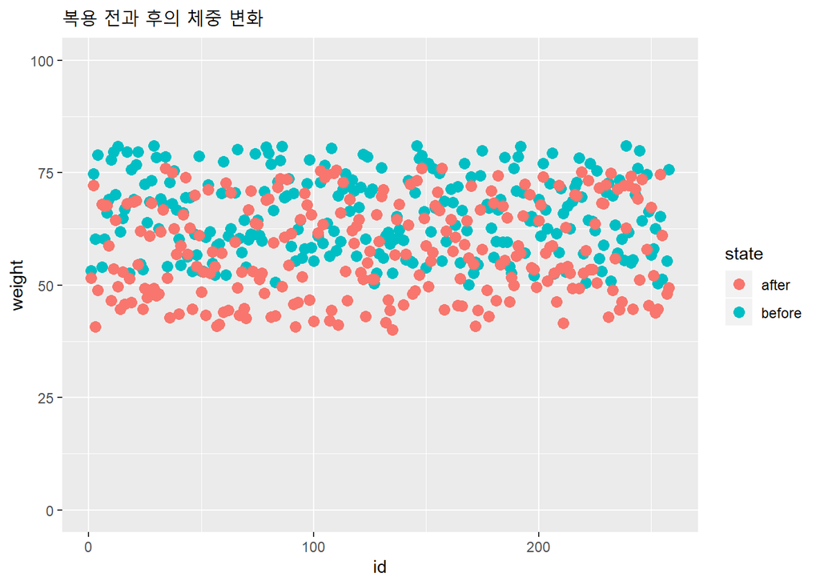

```r
library(ggplot2)
ggplot(data = result, aes(x=id, y=weight, colour=state)) +
  ylim(0, 100) +
  geom_point(size=3) +
  ggtitle("복용 전과 후의 체중 변화")
```

복용 전보다 복용 후의 체중이 전체적으로 감소함을 확인할 수 있다.

**2) 2개 몸무게 집단 분포 모양이 비슷한지를 검정하세요.**

```r
t.test(data = result, weight~state, var.equal =T)
```

```
##
##  Two Sample t-test
##
## data:  weight by state
## t = -8.8728, df = 496, p-value < 2.2e-16
## alternative hypothesis: true difference in means is not equal to 0
## 95 percent confidence interval:
##  -9.380043 -5.978993
## sample estimates:
##  mean in group after mean in group before
##             57.94016             65.61968
```

- *p-value < 2.2e-16 : 0.05미만이므로, 집단 간 차이가 통계적으로 유의함을 확인 할 수 있다.*

before(복용 전 몸무게)는 65.62, after(복용 후 몸무게)는 57.94이므로, 다이어트 보조제 복용 전보다 복용 후가 몸무게가 낮다. 이를 통해 체중 감량을 위해 섭취한 다이어트 보조제의 효과가 있음을 확인할 수 있다.

## 2. 범죄 상관관계 행렬

```r
# 데이터 읽기
library(readr)
crime_raw <- read_csv('data/crime_in_Seoul_include_gu_name.csv')
crime <- as.data.frame(crime_raw)
```

데이터를 가져와 데이터 프레임으로 그려준다.

```r
crime <- crime %>%
  select(-X1)
```

필요없는 데이터를 생략한다.

```r
# 상관관계 행렬로 나타내기
head(crime)
```

```
##     관서명 살인 발생 살인 검거 강도 발생 강도 검거 강간 발생 강간 검거
## 1   중부서         2         2         3         2       105        65
## 2   종로서         3         3         6         5       115        98
## 3 남대문서         1         0         6         4        65        46
## 4 서대문서         2         2         5         4       154       124
## 5   혜화서         3         2         5         4        96        63
## 6   용산서         5         5        14        14       194       173
##   절도 발생 절도 검거 폭력 발생 폭력 검거     구별
## 1      1395       477      1355      1170     중구
## 2      1070       413      1278      1070   종로구
## 3      1153       382       869       794     중구
## 4      1812       738      2056      1711 서대문구
## 5      1114       424      1015       861   종로구
## 6      1557       587      2050      1704   용산구
```

```r
crime_num <- crime %>%
  select(-c(관서명, 구별))

crime_cor <- cor(crime_num)
round(crime_cor, 2)
```

```
##           살인 발생 살인 검거 강도 발생 강도 검거 강간 발생 강간 검거 절도 발생
## 살인 발생      1.00      0.95      0.64      0.49      0.62      0.57      0.66
## 살인 검거      0.95      1.00      0.65      0.51      0.58      0.57      0.65
## 강도 발생      0.64      0.65      1.00      0.87      0.75      0.80      0.74
## 강도 검거      0.49      0.51      0.87      1.00      0.60      0.74      0.71
## 강간 발생      0.62      0.58      0.75      0.60      1.00      0.92      0.81
## 강간 검거      0.57      0.57      0.80      0.74      0.92      1.00      0.84
## 절도 발생      0.66      0.65      0.74      0.71      0.81      0.84      1.00
## 절도 검거      0.58      0.59      0.70      0.72      0.78      0.83      0.89
## 폭력 발생      0.75      0.80      0.79      0.70      0.76      0.80      0.90
## 폭력 검거      0.76      0.81      0.80      0.70      0.76      0.80      0.89
##           절도 검거 폭력 발생 폭력 검거
## 살인 발생      0.58      0.75      0.76
## 살인 검거      0.59      0.80      0.81
## 강도 발생      0.70      0.79      0.80
## 강도 검거      0.72      0.70      0.70
## 강간 발생      0.78      0.76      0.76
## 강간 검거      0.83      0.80      0.80
## 절도 발생      0.89      0.90      0.89
## 절도 검거      1.00      0.85      0.85
## 폭력 발생      0.85      1.00      1.00
## 폭력 검거      0.85      1.00      1.00
```

숫자 데이터만 남기기 위해 문자 데이터가 있는 컬럼을 제외한 후, 상관관계 행렬을 표현한다.

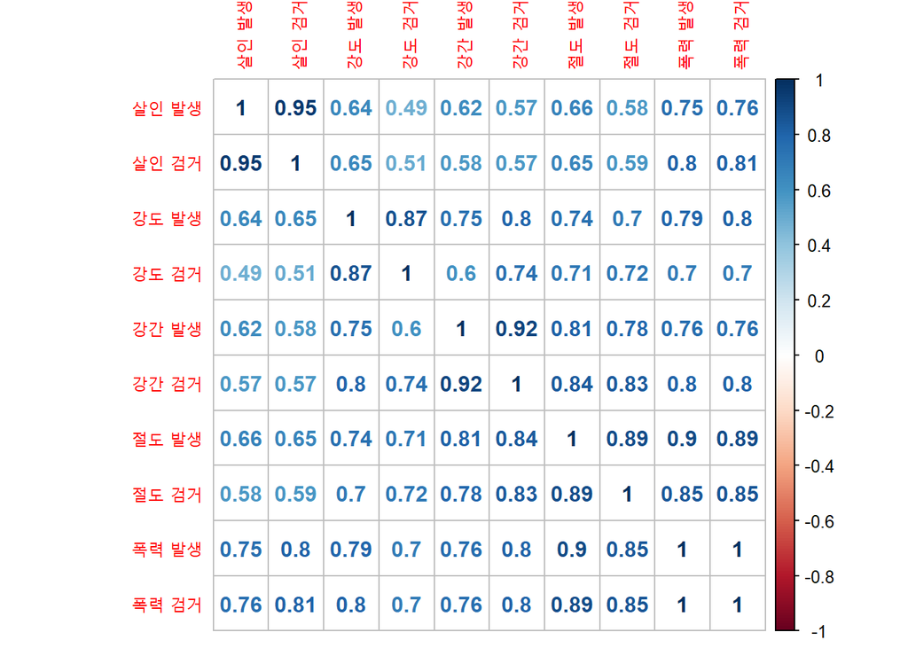

```r
library(corrplot)
corrplot(crime_cor, method='number')
```

가독성을 높이기 위해 plot형태로 만든다.

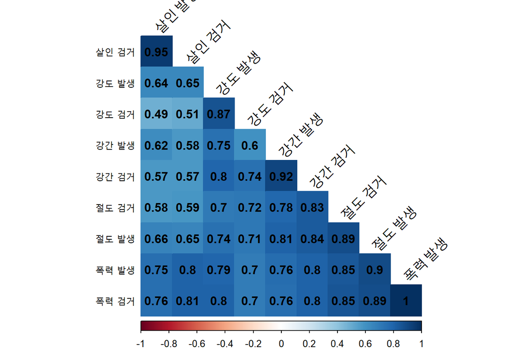

```r
corrplot(crime_cor,
         method = "color",        # 색깔로 표현
         type = 'lower',          # 왼쪽 아래 행렬만 표시
         order = 'hclust',        # 유사한 상관계수끼리 군집화
         addCoef.col = 'black',   # 상관계수 표시 색
         tl.col = 'black',        # 변수명 표시 색
         tl.srt = 45,             # 변수명 기울기 각도
         diag = F)                # 대각행렬(본인과의 상관계수) 제외
```